# Mergers with complements: the case of Claro, Colombia

May 17, 2016

## Overview

- Assess the effects of the merger Telmex-Comcel (now Claro).
  - Focus on effects on speeds and prices of hardwired internet.
- Provide an explanation for the increase in speeds.
  - Supply side: economies of scope, cost sinergies.
  - Demand side: goods are complements.
- The merger had competitive effects
  - Speeds increased, prices did not.
  - Complementarities are the best explanation.

## Background

## The merger that didn't happen

The merger on the news…

[figure not shown]

## The merging parties

Comcel was the largest cellphone carrier (voice, SMS and two types of mobile Internet: cellphone and USB modem) at the time of the merger:

- 93% of cities and towns
- almost 70% market share
- almost 70% of handsets sold

Telmex was the largest triple-play provider (land-line phone, Cable TV and Internet):

- present in 24 of 33 states
- average market share was 39%

## The effects of the merger

## First evidence of the effect of the merger

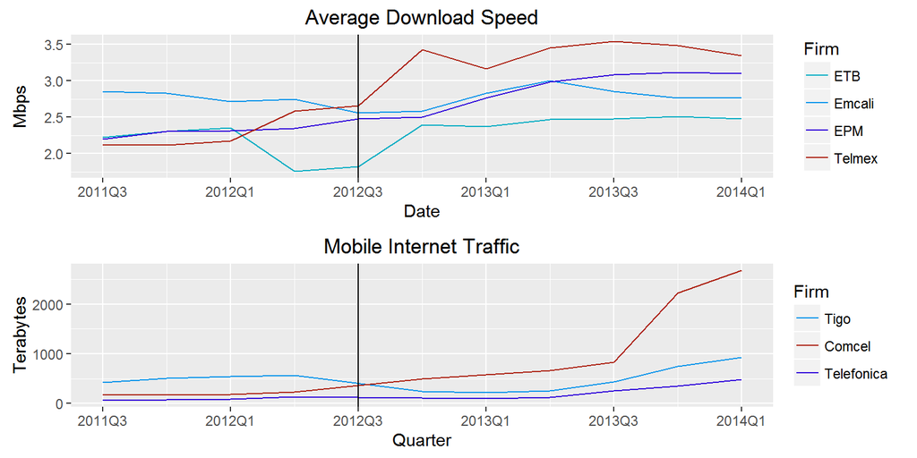

## The effect of the merger: more details

- In equilibrium the effects should extend beyond the merging firms.
- I assess three types of effects:
  - Effect on the merging firms,
  - effect on their competitors, and
  - average effect on markets.
- I compare the download speeds of:
  - the merging ISP and its largest competitors
  - merging firm's competitors and other similar firms.
  - markets affected by the merger and markets not affected by it.

## The diff-in-diff design

I estimate the following:

\[ y_{fct} = \phi_0 + \phi_1 TELMEX_f + \phi_2 AFTER_t +\\ \phi_3 TELMEX_f \times AFTER_t +\\ \delta_{st} + \phi_f + \varepsilon_{fct} \]

\[ y_{fct} = \gamma_0 + \gamma_1 FACES\_MERGER_f + \gamma_2 AFTER_t +\\ \gamma_3 FACES\_MERGER_f \times AFTER_t +\\ \delta_{st} + \gamma_f + \varepsilon_{fct} \]

\[ y_{ct} = \alpha_0 + \alpha_1 AFTER_t + \alpha_2 MERGER_c +\\ \alpha_3 AFTER_t \times MERGER_c + \varepsilon_{ct} \]

## Results: merged firm's speed

| Effect of mergers on mean speed | Effect of mergers on mean speed Model 1 Estimate | Effect of mergers on mean speed Model 1 Std. Error | Effect of mergers on mean speed Model 1 | Effect of mergers on mean speed | Effect of mergers on mean speed Model 2 Estimate | Effect of mergers on mean speed Model 2 Std. Error | Effect of mergers on mean speed Model 2 |
| --- | --- | --- | --- | --- | --- | --- | --- |
| Intercept | 0.73 | 0.17 | *** |  | 0.59 | 0.20 | ** |
| Post | 1.31 | 0.15 | *** |  | 1.73 | 0.26 | *** |
| Telmex | 1.41 | 0.19 | *** |  | 1.53 | 0.22 | *** |
| Telmex/post | 1.29 | 0.15 | *** |  | 1.25 | 0.26 | *** |
| adj. R-squared | 0.59 |  |  |  | 0.55 |  |  |
| Observations | 7,891 |  |  |  | 7,029 |  |  |

<sub>Dependent Variable: Median download speed(Mbps). Model 1: state and firm-quarter FE. Model 2: same as 1 but drops plans affected by the confounding policies. Signif. codes: 0(***) 0.001(**) 0.01(*) 0.05(.). Standard errors clusetered at firm-city-quarter level.</sub>

- The merged ISP increased download speeds by about 1.2 Mbps.

## Effect on rivals' speed

| Effect of mergers on mean speed | Effect of mergers on mean speed Model 1 Estimate | Effect of mergers on mean speed Model 1 Std. Error | Effect of mergers on mean speed Model 1 | Effect of mergers on mean speed | Effect of mergers on mean speed Model 2 Estimate | Effect of mergers on mean speed Model 2 Std. Error | Effect of mergers on mean speed Model 2 |
| --- | --- | --- | --- | --- | --- | --- | --- |
| Intercept | -58.43 | 224.54 |  |  | -58.27 | 224.64 |  |
| After | -0.19 | 0.19 |  |  | -0.19 | 0.19 |  |
| Competes with merged | -0.28 | 0.12 | * |  | -0.28 | 0.12 | * |
| After/Competes with merged | 0.46 | 0.19 | * |  | 0.46 | 0.19 | * |
| Coltel |  |  |  |  | 0.01 | 0.01 |  |
| adj. R-squared | .73 |  |  |  | 0.78 |  |  |
| Observations | 4,536 |  |  |  | 4,131 |  |  |

<sub>Dependent Variable: Mean download speed(Mbps). Model 1: state and firm-quarter FE. Model 2: same as 1 but drops plans affected by the confounding policies. Signif. codes: 0(***) 0.001(**) 0.01(*) 0.05(.). Standard errors clusetered at firm-city-quarter level.</sub>

- Competitors increased speeds by about .5 Mbps.

## Results: cities' speed

| Mean download speed in city | Mean download speed in city Model 1 Estimate | Mean download speed in city Model 1 Std. Error | Mean download speed in city Model 1 | Mean download speed in city | Mean download speed in city Model 2 Estimate | Mean download speed in city Model 2 Std. Error | Mean download speed in city Model 2 |
| --- | --- | --- | --- | --- | --- | --- | --- |
| Intercept | -346.61 | 68.95 | *** |  | -346.92 | 68.9 | *** |
| After | 0.04 | 0.07 |  |  | 0.04 | 0.07 |  |
| Merger | 0.1 | 0.11 |  |  | 0.1 | 0.11 |  |
| After/Merger | 0.64 | 0.12 | *** |  | 0.64 | 0.12 | *** |
| Coltel |  |  |  |  | -0.06 | 0.24 |  |
| adj. R-squared | 0.76 |  |  |  | 0.76 |  |  |
| Observations | 4,993 |  |  |  | 4,993 |  |  |

<sub>Speed in Mbps. Model 1: city fixed effects. Model 2: same as 1 controlling for Coltel's presence. Signif. codes: 0(***) 0.001(**) 0.01(*) 0.05(.). Standard errors clustered at city/quarter level.</sub>

- In cities where the merger took place speeds increased by 0.6 Mbps.

## Summary of the effects

- The merged increased speeds (by at least 1.2 Mbps).
- Rivals increased median speeds (.5 Mbps) but reduced their maxima.
- Median speed in cities were the merger happened increased (.6 Mbps).
- Results robust:
  - falsification test
  - by strata
  - propensity score

## Why would speeds increase?

## Two kinds of reasons

- Supply side: the ISP reduces costs after the merger
  - access to pre-existing mobile networks
  - know-how from the mobile firm
  - acquisition of new assets
- Demand side: the goods sold by the merging parties are complements.
  - Consumers demanding broadband are more likely to demand mobile services.
  - The merger internalizes profits.

## Cost reductions are not it!

- No good data to prove it. However,
  - increase in speeds is abrupt and widespread,
  - engineering craft, although related is not transferable, and
  - mobile networks are naturally congested (Calabrese (2013))

## The theory of mergers of complements

There is a handful of papers examining the behavior of merging firms that, that prior the merger, produce complementary goods

- Spector (2007)
- Choi (2008)
- Peitz (2008)
- Anderson, Loertscher, and Schneider (2010)
- Flores-Fillol and Moner-Colonques (2011)

Takeaway: Mergers of complements have potential for competitive effects

## Utility and substitution patterns

Following Gentzkow (2007)

- Suppose two goods A and B.
- Defining \(\Gamma = (u'_{AB}-u'_B)-(u'_A-u'_0)\), the utility of consuming the individual goods and a bundle can be written as

\[u_A=\delta_A - \alpha p_A + \nu_A\] \[u_B=\delta_B - \alpha p_B + \nu_B\] \[u_{AB}=u_A + u_B + \Gamma\] \[\left[ \begin{matrix} \nu_A \\ \nu_B \\ \end{matrix} \right] \sim N\left(\begin{matrix} 0 & \sigma \\ \sigma & 0 \\ \end{matrix}\right)\]

## Utility and substitution patterns

- The choice probabilities for utility-maximizing consumers are given by

\[q_A = \int_u I(u_A \ge 0)I(u_A \ge u_B)I(u_A \ge u_{AB})dF(\mathbf{u})\] \[q_B =\int_u I(u_B \ge 0)I(u_B\ge u_A)I(u_B \ge u_{AB})dF(\mathbf{u})\] \[q_{AB} =\int_u I(u_{AB} \ge 0)I(u_{AB}\ge u_A)I(u_{AB} \ge u_B)dF(\mathbf{u})\]

- Define \(Q_A = q_A +q_{AB}\) and \(Q_B = q_B + q_{AB}\)
- Now the sign of \(\frac{\partial Q_A}{\partial p_B}\) determines the substitution pattern

## Price of B increases and Γ = 0

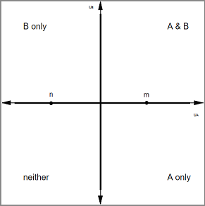

- \(m\) substitutes \(AB\) for \(A\): \(\uparrow q_A = \downarrow q_{AB}\) and \(Q_A\) remains unchanged.
- \(n\) has no impact on \(Q_A\)
- Hence \(\Gamma = 0\) implies \(\frac{\partial Q_A}{\partial p_B}=0\) (goods are independent)

## Price of B increases and Γ > 0

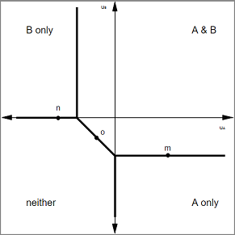

## Price of B increases and Γ < 0

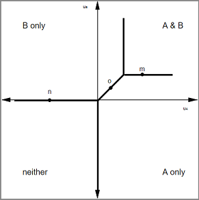

- \(m\) substitutes \(AB\) for \(A\): \(\uparrow q_A = \downarrow q_{AB}\)
- \(o\) substitutes \(B\) for \(A\): \(\uparrow q_A\) and overall \(\uparrow Q_A\)
- Hence \(\Gamma < 0\) implies \(\frac{\partial Q_A}{\partial p_B}>0\) (goods are substitutes)

## Empirical demand (I)

- 4 individual goods \(h \in \{1,2,3,4\}\)
- 16 possible bundles \(j \in \{0,1,...,15\}\)
- Quarters are indexed by \(t\), cities by \(c\) and consumers by \(i=\{1,2...,N\}\)
- The utility of consuming an individual good \(h\) is given by

\[\bar{u}_{ihct} = p_{hct} \bar{\alpha}_i + \sum_k x_{hk} \bar{\beta}_{ik} + \xi_{h}\]

\[\bar{\alpha}_i = \alpha + \sum_r z_{ir}\alpha_r^o + \nu_{ip} \alpha^u \] \[\bar{\beta}_{ik} = \beta_k + \sum_r z_{ir}\beta_{kr}^o + \nu_{ik} \beta_k^u \]

## Empirical demand (II)

- Second, the utility of a bundle j can be written as

\[u_{ijct} = \begin{cases} \varepsilon_{ijct}, & \text{if } j=0 \\[2ex] \sum_{h \in j} \bar{u}_{ihct}+ \Gamma_j +\varepsilon_{ijct}, & \text{if } j >0 \end{cases}\]

- ε <sub>ijct</sub> is assumed to be distributed T1EV
- Γ <sub>j</sub> is zero for singleton bundles.

## Empirical demand (III)

- Integrating over the εs the choice probability for bundle j, is

\[s_{jct} =\int_\nu \int_z \frac{\exp \left[\sum_{h \in j} u_{ihct}+ \Gamma_j \right]}{1 + \sum_{m=1}^{15} \left[\exp \sum_{h \in m} u_{ihct}+ \Gamma_m \right] }dF_\nu dF_z \]

- From here I follow Berry(1994)
  - For given parameter values (logit estimates) simulate the shares
  - Contraction mapping to find mean utilities
  - Construct error term
  - Minimize the objective function

## Data

- Market shares in almost 1,000 markets in 2015
- Characteristics of bundle: price, speeds, type of connection, has premium channels, has HD channels, has video on demand, gigabyte included for mobile internet…
- I focus on residential services even though the data includes business plans.

| Table 7: Summary bundles 2015 | Table 7: Summary bundles 2015 Mean Price ($) | Table 7: Summary bundles 2015 Std. Dev | Table 7: Summary bundles 2015 Market Share | Table 7: Summary bundles 2015 Subscribers (Million) |
| --- | --- | --- | --- | --- |
| Internet | 19.3 | 9.2 | 0.090 | 2.25 |
| Mobile | 17.6 | 9.4 | 0.030 | 0.75 |
| Phone | 17.1 | 8.6 | 0.010 | 0.25 |
| TV | 19.9 | 9.1 | 0.010 | 0.25 |
| Internet/Mobile | 34.5 | 11.2 | 0.012 | 0.30 |
| Internet/Phone | 31.2 | 15.1 | 0.092 | 2.30 |
| Internet/TV | 31.0 | 14.0 | 0.003 | 0.08 |
| Mobile/Phone | 35.7 | 15.9 | 0.023 | 0.58 |
| Mobile/TV | 37.4 | 19.1 | 0.034 | 0.85 |
| Phone/TV | 57.1 | 21.4 | 0.011 | 0.28 |
| Internet/Mobile/Phone | 64.9 | 25.2 | 0.091 | 2.28 |
| Internet/Mobile/TV | 63.7 | 23.4 | 0.082 | 2.05 |
| Internet/Phone/TV | 66.9 | 24.1 | 0.310 | 7.75 |
| Mobile/Phone/TV | 66.6 | 23.5 | 0.001 | 0.03 |
| Internet/Mobile/Phone/TV | 81.4 | 28.3 | 0.210 | 5.25 |

## Substitution patterns

The estimation algorithm is initialized with Logit estimates

| Estimated substitution patterns | Estimated substitution patterns Interaction Γ<sub>j</sub> | Estimated substitution patterns Std. Error | Estimated substitution patterns Sign. Codes |
| --- | --- | --- | --- |
| Internet/Mobile | 1.34 | 0.27 | *** |
| Internet/Phone | 0.82 | 0.13 | *** |
| Internet/TV | -1.78 | 1.69 |  |
| Mobile/Phone | -2.1 | 0.57 | *** |
| Mobile/TV | 0.01 | 0.01 |  |
| Phone/TV | 1.03 | 1.41 |  |
| Internet/Mobile/Phone | 0.95 | 0.12 | *** |
| Internet/Mobile/TV | 1.29 | 0.31 | *** |
| Internet/Phone/TV | 1.16 | 0.25 | *** |
| Mobile/Phone/TV | 0.78 | 1.14 |  |
| Internet/Mobile/Phone/TV | 0.1 | 0.01 | *** |

## Substitution patterns: substitutes

| Estimated substitution patterns | Estimated substitution patterns Interaction Γ<sub>j</sub> | Estimated substitution patterns Std. Error | Estimated substitution patterns Sign. Codes |
| --- | --- | --- | --- |
| Internet/Mobile | 1.34 | 0.27 | *** |
| Internet/Phone | 0.82 | 0.13 | *** |
| Internet/TV | -1.78 | 1.69 |  |
| Mobile/Phone | -2.1 | 0.57 | *** |
| Mobile/TV | 0.01 | 0.01 |  |
| Phone/TV | 1.03 | 1.41 |  |
| Internet/Mobile/Phone | 0.95 | 0.12 | *** |
| Internet/Mobile/TV | 1.29 | 0.31 | *** |
| Internet/Phone/TV | 1.16 | 0.25 | *** |
| Mobile/Phone/TV | 0.78 | 1.14 |  |
| Internet/Mobile/Phone/TV | 0.1 | 0.01 | *** |

## Substitution patterns: complements

| Estimated substitution patterns | Estimated substitution patterns Interaction Γ<sub>j</sub> | Estimated substitution patterns Std. Error | Estimated substitution patterns Sign. Codes |
| --- | --- | --- | --- |
| Internet/Mobile | 1.34 | 0.27 | *** |
| Internet/Phone | 0.82 | 0.13 | *** |
| Internet/TV | -1.78 | 1.69 |  |
| Mobile/Phone | -2.1 | 0.57 | *** |
| Mobile/TV | 0.01 | 0.01 |  |
| Phone/TV | 1.03 | 1.41 |  |
| Internet/Mobile/Phone | 0.95 | 0.12 | *** |
| Internet/Mobile/TV | 1.29 | 0.31 | *** |
| Internet/Phone/TV | 1.16 | 0.25 | *** |
| Mobile/Phone/TV | 0.78 | 1.14 |  |
| Internet/Mobile/Phone/TV | 0.1 | 0.01 | *** |

## Substitution patterns: independents

| Estimated substitution patterns | Estimated substitution patterns Interaction Γ<sub>j</sub> | Estimated substitution patterns Std. Error | Estimated substitution patterns Sign. Codes |
| --- | --- | --- | --- |
| Internet/Mobile | 1.34 | 0.27 | *** |
| Internet/Phone | 0.82 | 0.13 | *** |
| Internet/TV | -1.78 | 1.69 |  |
| Mobile/Phone | -2.1 | 0.57 | *** |
| Mobile/TV | 0.01 | 0.01 |  |
| Phone/TV | 1.03 | 1.41 |  |
| Internet/Mobile/Phone | 0.95 | 0.12 | *** |
| Internet/Mobile/TV | 1.29 | 0.31 | *** |
| Internet/Phone/TV | 1.16 | 0.25 | *** |
| Mobile/Phone/TV | 0.78 | 1.14 |  |
| Internet/Mobile/Phone/TV | 0.1 | 0.01 | *** |

## Final remarks

- The merger had competitive effects: equilibrium download speeds increased more than prices.
- There is evidence of strong complementary preferences for the goods offered by the merging firms.

What now?

- Simulate counterfactuals:
  - Bogotá's governemnt's decision of selling controlling stake in ETB.
  - Welfare if the marger had not happened.
- Re-assess the effect of subsidies to Internet access.

## Logit (1)

\[ln(s_j)- ln(s_0) = \alpha \sum_{h \in j} price_h +\sum_{h \in j} \sum_k x_{hk} \beta_k + \varepsilon_j\]

Where \(h\) are individual goods included in bundle \(j\) and \(x_{hk}\) are goods features:

- number of minutes included (cellphone + land-line)
- avg price additional minute (cellphone + land-line)
- download speed (Mbps)
- number of SMS included
- price additional sms
- Dummy for type of internet connection and TV
- TV has:
  - video on demand
  - HD channels
  - premium channels

## Logit (2)

| Estimated substitution patterns | Estimated substitution patterns Interaction Γ<sub>j</sub> | Estimated substitution patterns Std. Error | Estimated substitution patterns Sign. Codes |
| --- | --- | --- | --- |
| Internet/Mobile | -0.32 | 0.14 | ** |
| Internet/Phone | 0.69 | 0.11 | *** |
| Internet/TV | -1.25 | 1.32 |  |
| Mobile/Phone | -3.1 | 0.62 | *** |
| Mobile/TV | 0.01 | 0.01 |  |
| Phone/TV | 1.48 | 1.41 |  |
| Internet/Mobile/Phone | 0.87 | 0.15 | *** |
| Internet/Mobile/TV | 1.34 | 0.31 | *** |
| Internet/Phone/TV | -0.05 | 0.02 | ** |
| Mobile/Phone/TV | 0.89 | 1.02 |  |
| Internet/Mobile/Phone/TV | 0.35 | 2.1 |  |

(go back)

## References

Anderson, Simon P., Simon Loertscher, and Yves Schneider. 2010. “The ABC of Complementary Products Mergers.” *Economics Letters* 106 (3): 212–15. doi:10.1016/j.econlet.2009.11.022.

Calabrese, Michael. 2013. “Solving the Spectrum Crunch: Unlicensed Spectrum on a High-Fiber Diet.” *TWC Research Program on Digital Communications*.

Choi, Jay Pil. 2008. “Mergers with Bundling in Complementary Markets.” *The Journal of Industrial Economics* 56 (3). wiley: 553–77. doi:10.1111/j.1467-6451.2008.00352.x.

Flores-Fillol, Ricardo, and Rafael Moner-Colonques. 2011. “Endogenous Mergers of Complements with Mixed Bundling.” *Review of Industrial Organization* 39 (3): 231–51. doi:10.1007/s11151-011-9281-0.

Gentzkow, Matthew. 2007. “Valuing New Goods in a Model with Complementarity: Online Newspapers.” *American Economic Review* 97 (3): 713–44. doi:10.1257/aer.97.3.713.

Peitz, Martin. 2008. “Bundling May Blockade Entry.” *International Journal of Industrial Organization* 26 (1): 41–58. doi:10.1016/j.ijindorg.2006.09.005.

Spector, David. 2007. “Bundling, Tying, and Collusion.” *International Journal of Industrial Organization* 25 (3): 575–81. doi:10.1016/j.ijindorg.2006.06.003.